# Assignment 3

John Chen

March 01, 2024

# Introduction

This report aims to answer the question: When and where do most wild fires occur? The [Fire Program Analysis fire-occurrence database](https://www.kaggle.com/datasets/rtatman/188-million-us-wildfires?rvi=1) 1.88 million recorded wild fires in the US from 1992 to 2015. The interest for this investigation was sparked by an sudden increase of wild fires around the world. I wish to examine the pattern in frequencies, more importantly, the irregularities in frequency of occurrences. It is expected that frequencies are impacted by the occurrences of other environmental disasters, like rains and hurricanes. This report is only meant to gain basic insight into the frequencies of fires throughout a long period of time. This data set contains the discovery date of the fire, the acres burned, location of the fire, and the cause of fire.

# Method

To examine patterns in wild fire frequency, I will make histogram of year to see if there is an increasing or decreasing pattern. If there is an increasing pattern, it supports the claim that frequency of wild fire increases throughout time(both year and season will be examined). Spatial plots will be used to see the location of wild fire hot spots in the US during the time that would be concluded as the worst fire season. A chi-square test will be conducted on causes and season to see if there are any correlation. If there are, we should identify the combination of the two that relatively causes the most fires. Since wild fires is a good fit for poisson distribution, I will use GLM to examine which values of variables generates the most amount of wild fire.

# Results

```r
julian_origin <- lubridate::ymd("0000-11-25") - lubridate::years(4713)
wildfire$DISCOVERY_DATE <- as.Date(wildfire$DISCOVERY_DATE, origin = julian_origin)
wildfire$DISCOVERY_TIME <- as_hms(strptime(wildfire$DISCOVERY_TIME, "%H%M"))

wildfire$CONT_DATE <- as.Date(wildfire$CONT_DATE, origin = julian_origin)
wildfire$CONT_TIME <- as_hms(strptime(wildfire$CONT_TIME, "%H%M"))
```

[figure not shown]

```r
wildfire <- wildfire[c("STATE","FIRE_YEAR","DISCOVERY_DATE","DISCOVERY_DOY","DISCOVERY_TIME", "STAT_CAUSE_DESCR","CONT_DATE","CONT_DOY","CONT_TIME", "FIRE_SIZE", "FIRE_SIZE_CLASS", "LATITUDE", "LONGITUDE", "COUNTY")]
summary(wildfire)
```

```r
wildfire <- wildfire %>%
  mutate(
    SEASON = case_when(
      month(DISCOVERY_DATE) %in% c(12,1,2) ~ "winter",
      month(DISCOVERY_DATE) %in% 3:5 ~ "spring",
      month(DISCOVERY_DATE) %in% 6:8 ~ "summer",
      month(DISCOVERY_DATE) %in% 9:11 ~ "fall"
    )
  )
wildfire$SEASON <- factor(wildfire$SEASON, levels = c("spring", "summer", "fall", "winter"))
wildfire$STAT_CAUSE_DESCR <- factor(wildfire$STAT_CAUSE_DESCR)
wildfire$FIRE_SIZE_CLASS <- factor(wildfire$FIRE_SIZE_CLASS, levels = c("A", "B", "C", "D", "E", "F", "G"))
```

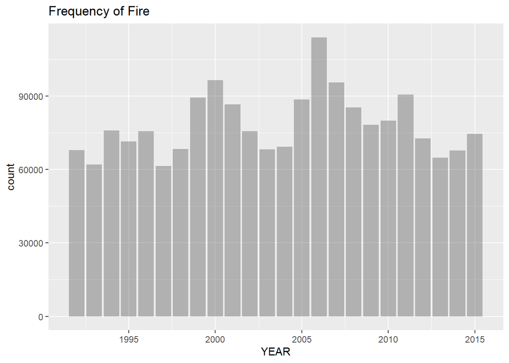

Figure 1

```r
wildfire %>%
  ggplot() +
  geom_bar(aes(x=FIRE_YEAR),position="identity", alpha=0.4) +
  labs(x="YEAR", title = "Frequency of Fire")
```

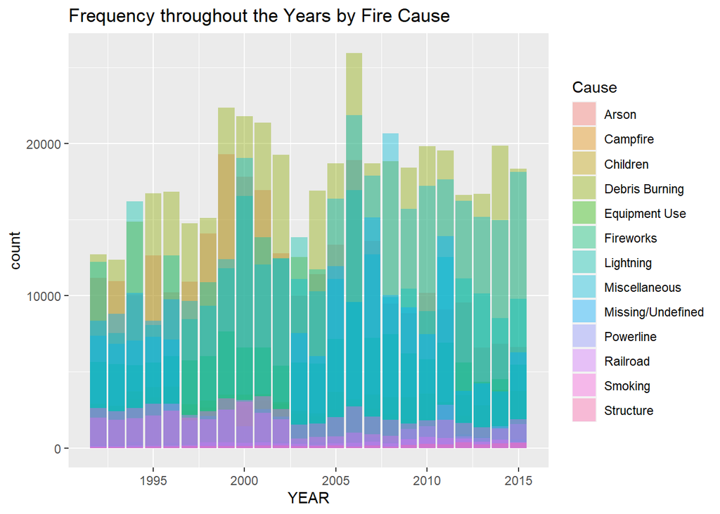

Figure 1

```r
wildfire %>%
  ggplot() +
  geom_bar(aes(x=FIRE_YEAR,fill=STAT_CAUSE_DESCR),position="identity", alpha=0.4) +
  labs(x="YEAR", title = "Frequency throughout the Years by Fire Cause", fill="Cause")
```

The frequencies of fire has not increased throughout the years. There does not seem to be a pattern for any distribution.

## Which combination of season and causation has the highest frequency?

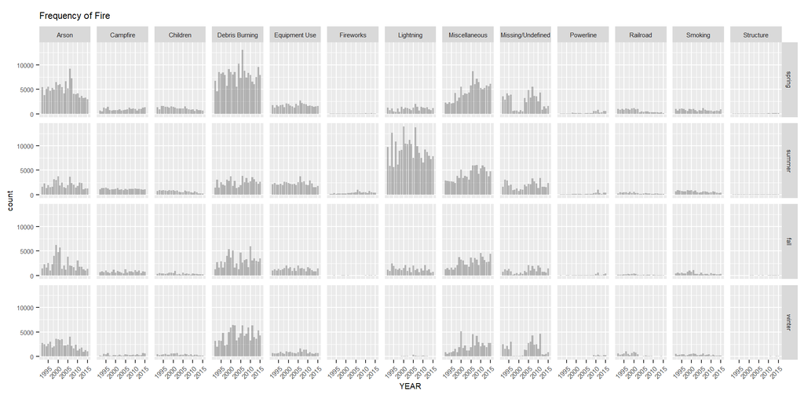

```r
wildfire %>%
  ggplot() +
  geom_bar(aes(x=FIRE_YEAR),position="identity", alpha=0.4) +
  labs(x="YEAR", title = "Frequency of Fire") +
  facet_grid(SEASON ~ STAT_CAUSE_DESCR) +
  theme(text = element_text(size = 7)) +
  coord_fixed(ratio = 2/800) +
  theme(axis.text.x = element_text(angle = 45, hjust = 1))
```

```r
con <- table(wildfire$STAT_CAUSE_DESCR, wildfire$SEASON)
matrix <- apply(as.matrix.noquote(con),2,as.numeric)
chi <- chisq.test(con)
tidy_chi <- tidy(chi)
tidy_chi <- tidy_chi %>% select(-method)
kable(tidy_chi, format = "markdown", col.names = c("chi-squared statistic", "p-value", "degrees of freedom")) %>%
  kable_styling(full_width = FALSE) %>%
  column_spec(2, bold = TRUE, color = "red") %>%
  add_header_above(c("Pearson's chi square test"=3))
```

| Pearson’s chi square test chi-squared statistic | Pearson’s chi square test p-value | Pearson’s chi square test degrees of freedom |
| --- | --- | --- |
| 425592.1 | 0 | 36 |

Based on a p-value smaller than 2.2e-16 from chi-sqaure, we can reject the null that season is independent from cause. This supports the fact that there is a relation between season and causation.

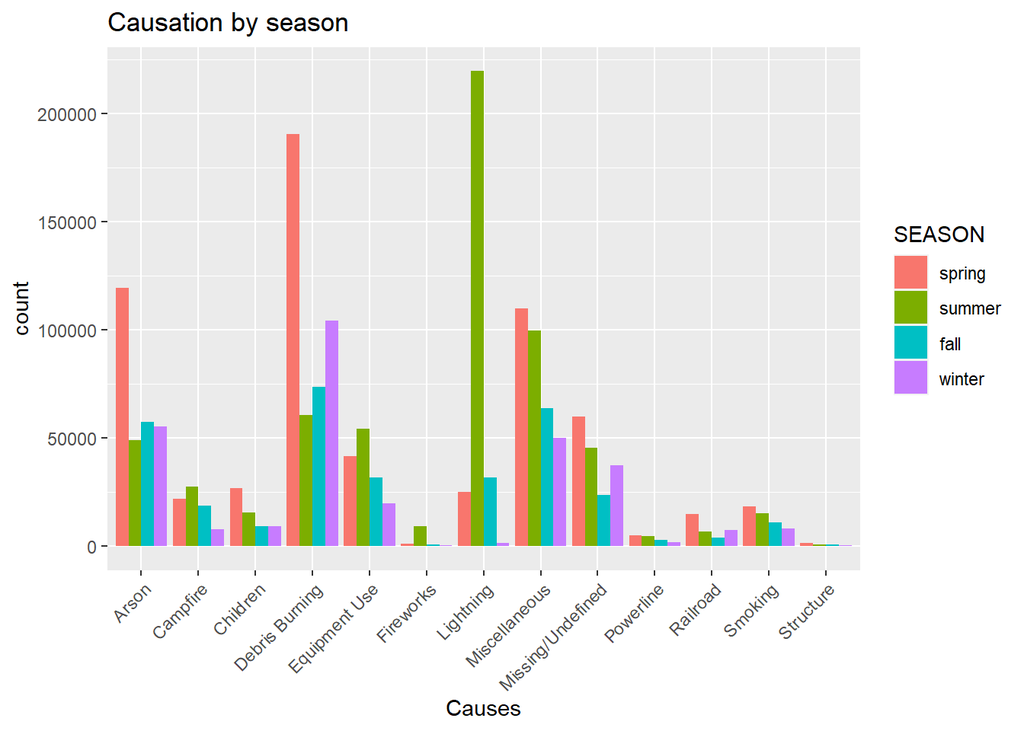

```r
wildfire %>%
  ggplot(aes(x=STAT_CAUSE_DESCR, fill=SEASON)) +
  geom_bar(position="dodge") +
  labs(title = "Causation by season", x = "Causes") +
  theme(axis.text.x = element_text(angle = 45, hjust = 1))
```

The frequency of fire is the highest during summer caused by lightning.

## Using generative linear model to see what increases the frequencies of fire per month.